# DDoS Attack Mitigation

When we preinitialize training coefficients, the length of the workload is equal to the length of the detection phase.

For a detection phase of 2^24 packets we have:

2^(24-log2m-2) OWs before the attack, 2^(24-log2m-1) OWs under attack, 2^(24-log2m-2) OWs after the attack.

2^8 OWs pre-attack and post attack,  
2^9 OWs under attack,

For m=2^16, 2^8 windows:

2^6 OWs pre-attack and post-attack, 2^7 OWs under attack.

For m=2^18, 2^6 windows:

2^4 OWs pre-attack and post-attack, 2^5 OWs under attack.

# Load the Dataset

## Add Index Column

```r
packets = packets %>% tibble::rowid_to_column("index")
packets
```

| index | src | dst | src_delta | dst_delta | attack |
| --- | --- | --- | --- | --- | --- |
| 1 | 155.178.77.42 | 153.193.161.196 | 0x00000000 | 0x00000000 | FALSE |
| 2 | 137.228.67.212 | 43.147.252.71 | 0x00000000 | 0x00000000 | FALSE |
| 3 | 152.0.239.103 | 0.0.0.0 | 0x00000000 | 0x00000000 | FALSE |
| 4 | 155.178.77.42 | 153.193.161.196 | 0x00000000 | 0x00000000 | FALSE |
| 5 | 221.46.220.110 | 74.79.109.223 | 0x00000000 | 0x00000000 | FALSE |
| 6 | 147.201.234.200 | 198.85.16.239 | 0x00000000 | 0x00000000 | FALSE |
| 7 | 101.6.162.56 | 102.0.232.202 | 0x00000000 | 0x00000000 | FALSE |
| 8 | 119.226.18.51 | 1.102.56.96 | 0x00000000 | 0x00000000 | FALSE |
| 9 | 137.228.67.212 | 43.147.252.71 | 0x00000000 | 0x00000000 | FALSE |
| 10 | 152.0.239.103 | 0.0.0.0 | 0x00000000 | 0x00000000 | FALSE |

[output cut: 990 more lines]

## Add OW Number Column

```r
packets = packets %>% mutate(ow = get_ow(index,m))
packets
```

| index | src | dst | src_delta | dst_delta | attack | ow |
| --- | --- | --- | --- | --- | --- | --- |
| 1 | 155.178.77.42 | 153.193.161.196 | 0x00000000 | 0x00000000 | FALSE | 513 |
| 2 | 137.228.67.212 | 43.147.252.71 | 0x00000000 | 0x00000000 | FALSE | 513 |
| 3 | 152.0.239.103 | 0.0.0.0 | 0x00000000 | 0x00000000 | FALSE | 513 |
| 4 | 155.178.77.42 | 153.193.161.196 | 0x00000000 | 0x00000000 | FALSE | 513 |
| 5 | 221.46.220.110 | 74.79.109.223 | 0x00000000 | 0x00000000 | FALSE | 513 |
| 6 | 147.201.234.200 | 198.85.16.239 | 0x00000000 | 0x00000000 | FALSE | 513 |
| 7 | 101.6.162.56 | 102.0.232.202 | 0x00000000 | 0x00000000 | FALSE | 513 |
| 8 | 119.226.18.51 | 1.102.56.96 | 0x00000000 | 0x00000000 | FALSE | 513 |
| 9 | 137.228.67.212 | 43.147.252.71 | 0x00000000 | 0x00000000 | FALSE | 513 |
| 10 | 152.0.239.103 | 0.0.0.0 | 0x00000000 | 0x00000000 | FALSE | 513 |

[output cut: 990 more lines]

## Convert Delta Values (Source and Destination)

```r
# Convert from hexadecimal to decimal
packets = packets %>% mutate_at(vars(src_delta, dst_delta), funs(strtoi))
```

[output not shown]

```r
# Convert from 16-bit two's complement notation to integer.
packets = packets %>% mutate_at(vars(src_delta, dst_delta), funs(twos_complement))

packets %>% filter(ow>770)
```

| index | src | dst | src_delta | dst_delta | attack | ow |
| --- | --- | --- | --- | --- | --- | --- |
| 4227073 | 107.188.228.19 | 74.55.244.199 | -13 | -13 | FALSE | 771 |
| 4227074 | 1.96.195.11 | 153.193.46.175 | 30 | 35 | FALSE | 771 |
| 4227075 | 146.17.52.91 | 120.19.162.90 | 99 | 99 | FALSE | 771 |
| 4227076 | 43.240.97.150 | 221.46.220.179 | -44 | -40 | FALSE | 771 |
| 4227077 | 146.59.155.66 | 153.193.46.202 | 1 | 2 | FALSE | 771 |
| 4227078 | 112.83.105.174 | 1.96.167.103 | 20 | 24 | FALSE | 771 |
| 4227079 | 146.2.215.128 | 119.31.135.105 | 6 | -6 | FALSE | 771 |
| 4227080 | 111.37.250.135 | 3.138.37.218 | -4 | 3 | FALSE | 771 |
| 4227081 | 161.69.48.219 | 161.69.45.5 | -118 | -126 | FALSE | 771 |
| 4227082 | 66.42.187.65 | 1.83.102.7 | 3 | -1 | FALSE | 771 |

[output cut: 990 more lines]

# Attack

At this point we need to check whether we can observe the first attack packet.

The attack occurs between windows (training_length + detection_length / 4 + 1) and (training_length + detection_length / 2).

```r
attack_start = m * (detection_length / 4 + 1) + 1
attack_start
```

```
[1] 4210689
```

Querying the dataset at the given points.

```r
packets %>% filter(index >= attack_start - m)
```

| index | src | dst | src_delta | dst_delta | attack | ow |
| --- | --- | --- | --- | --- | --- | --- |
| 4194305 | 221.32.72.235 | 1.32.254.156 | 0 | 0 | FALSE | 769 |
| 4194306 | 198.88.219.113 | 198.88.221.44 | 0 | 0 | FALSE | 769 |
| 4194307 | 43.139.101.159 | 1.34.26.143 | 0 | 0 | FALSE | 769 |
| 4194308 | 68.233.36.14 | 210.108.37.25 | 0 | 0 | FALSE | 769 |
| 4194309 | 192.120.148.227 | 71.126.222.64 | 0 | 0 | TRUE | 769 |
| 4194310 | 153.193.46.93 | 115.46.206.104 | 0 | 0 | FALSE | 769 |
| 4194311 | 51.173.229.255 | 71.126.222.64 | 0 | 0 | TRUE | 769 |
| 4194312 | 202.1.175.252 | 71.126.222.64 | 0 | 0 | TRUE | 769 |
| 4194313 | 192.95.27.190 | 71.126.222.64 | 0 | 0 | TRUE | 769 |
| 4194314 | 51.173.229.255 | 71.126.222.64 | 0 | 0 | TRUE | 769 |

[output cut: 990 more lines]

```r
NA
```

For log2m=14, the attack begins at the fifth packet of OW 769 and lasts for a total of 512 OWs (i.e., OWs 769-1280).

In OW 769 there is no packet diversion, since we have not set DEFCON yet. In OW 770 DEFCON is already set; the switch begins calculating deltas, using OWs 769 and 768 as a reference. (**Here I can see a potential problem - when we begin moving away from the beginning of the attack, we will have no information about addresses which are yet to appear! This means that I’ll have to keep updating counters during all of our story**).

## Overview

Get the stats for all but the first two OWs under attack: address frequencies for each delta value.

```r
query = packets %>% filter(ow >= 770, ow <= 1280) %>% group_by(ow, attack, src_delta) %>% summarize(sources=n_distinct(src))

query
```

| ow | attack | src_delta | sources |
| --- | --- | --- | --- |
| 770 | FALSE | -275 | 1 |
| 770 | FALSE | -197 | 1 |
| 770 | FALSE | -141 | 1 |
| 770 | FALSE | -82 | 1 |
| 770 | FALSE | -77 | 1 |
| 770 | FALSE | -75 | 1 |
| 770 | FALSE | -72 | 1 |
| 770 | FALSE | -63 | 2 |
| 770 | FALSE | -61 | 1 |
| 770 | FALSE | -54 | 1 |

[output cut: 990 more lines]

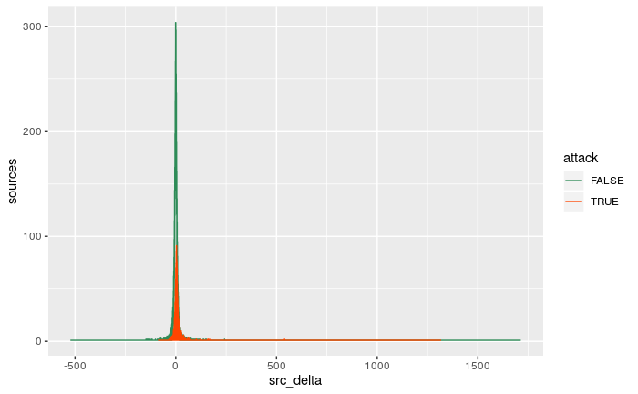

```r
query %>%
  ggplot(mapping=aes(x=src_delta, y=sources, color=attack)) +
  geom_line() +
  scale_color_manual(values=c("seagreen4", "orangered1"))
```

```r
# + coord_cartesian(xlim=c(0,1500),ylim=c(0,4000))
```

To analyze the behavior of our classifier, it would be interesting to plot a histogram using 16 (2^log2(m-10)) as a bin size.

## First Attack OWs

Let’s set an arbitrary threshold and a function which indicates whether or not to divert a given packet.

```r
threshold = 16
```

```r
#divert = function(src_delta, dst_delta) (src_delta >= threshold)
divert = function(src_delta, dst_delta) (dst_delta >= threshold)
#divert = function(src_delta, dst_delta) (src_delta >= threshold && dst_delta >= threshold)
```

```r
stats = function() {

  true_evil = query %>% filter(attack==TRUE) %>% tally()
  true_good = query %>% filter(attack==FALSE) %>% tally()
  message("True evil: ", true_evil, " True good: ", true_good, " Total: ", true_evil + true_good)

  class_evil = query %>% filter(divert(src_delta,dst_delta)) %>% tally()
  class_good = query %>% filter(!divert(src_delta,dst_delta)) %>% tally()
  message("Class evil: ", class_evil, " Class good: ", class_good, " Total: ", class_evil + class_good)

  error_evil = query %>% filter(!divert(src_delta,dst_delta), attack==TRUE)  %>% tally()
  error_good = query %>% filter(divert(src_delta,dst_delta), attack==FALSE) %>% tally()

  message("FNcount: ", error_evil, " FPcount: ", error_good, " Total: ", error_evil + error_good)
  message("FNR: ", round(error_evil/true_evil,4), " FPR: ", round(error_good/true_good,4))

}
```

Let’s analyze **only the first 30 OWs under attack**.

```r
first = 770 # Attack begins @769, mitigation begins @770.  OW = 2^14 = 16.384 packets. Proportion = 20%. => ~3200 "evil", rest "good".
last  = 800

query = packets %>% filter(ow>=first, ow<=last)

stats()
```

```
True evil: 101662 True good: 406242 Total: 507904
Class evil: 131342 Class good: 376562 Total: 507904
FNcount: 9338 FPcount: 39018 Total: 48356
FNR: 0.0919 FPR: 0.096
```

It would be interesting to observe what happens **over time**, OW after OW.

```r
graph_true_good = function() query %>% filter(attack==FALSE) %>% summarize(n=n()) %>% ggplot(mapping=aes(x=ow,y=n)) + geom_point() + ggtitle("True Good")
graph_true_evil = function() query %>% filter(attack==TRUE)  %>% summarize(n=n()) %>% ggplot(mapping=aes(x=ow,y=n)) + geom_point() + ggtitle("True Evil")

graph_class_good = function() query %>% filter(diverted==FALSE) %>% summarize(n=n()) %>% ggplot(mapping=aes(x=ow,y=n)) + geom_point() + ggtitle("Forwarded")
graph_class_evil = function() query %>% filter(diverted==TRUE)  %>% summarize(n=n()) %>% ggplot(mapping=aes(x=ow,y=n)) + geom_point() + ggtitle("Diverted")

graph_false_neg = function() query %>% filter(!divert(src_delta,dst_delta), attack==TRUE)  %>% summarize(n=n()) %>% ggplot(mapping=aes(x=ow,y=n)) + geom_point() + ggtitle("False Negatives")
graph_false_pos = function()  query %>% filter(divert(src_delta,dst_delta), attack==FALSE) %>% summarize(n=n()) %>% ggplot(mapping=aes(x=ow,y=n)) + geom_point() + ggtitle("False Positives")

graph_results = function()

  query %>% group_by(ow, attack, diverted) %>% summarize(n=n()) %>%
    ggplot(mapping=aes(x=ow, y=n, color=attack, shape=diverted)) +
    geom_point(position="jitter", size=2.0) +
    #coord_cartesian(xlim=c(770,810),ylim=c(0,16384)) +
    labs(x="Observation Window", y="Packet Count", title ="Classification Results") +
    scale_x_continuous(expand=expand_scale(add=0)) +
    scale_y_continuous(expand=expand_scale(add=0)) +
    scale_color_manual(values=c("seagreen4", "orangered1")) +
    theme_classic()
```

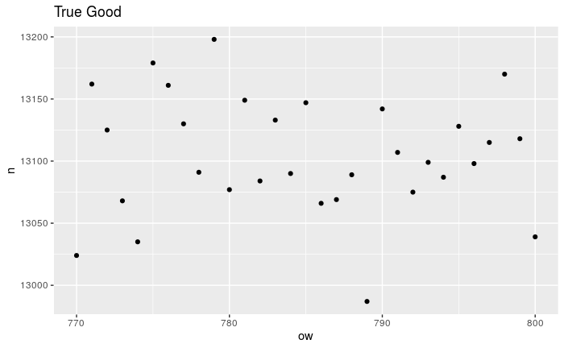

```r
first = 770
last  = 800

query = packets %>%
  filter(ow>=first, ow<=last) %>%
  mutate(diverted=divert(src_delta,dst_delta)) %>%
  group_by(ow)

graph_true_good()
```

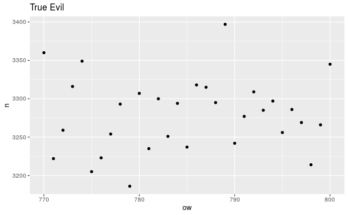

```r
graph_true_evil()
```

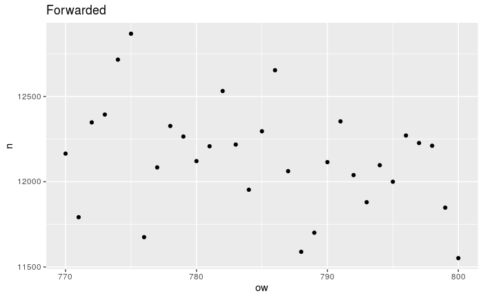

```r
graph_class_good()
```

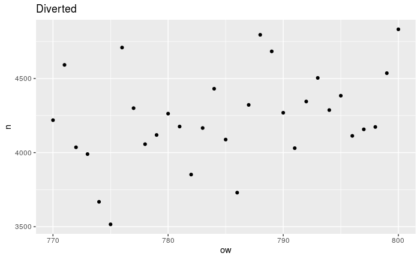

```r
graph_class_evil()
```

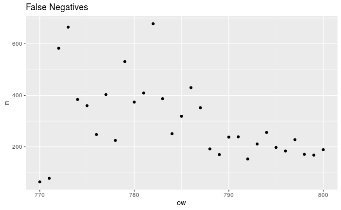

```r
graph_false_neg()
```

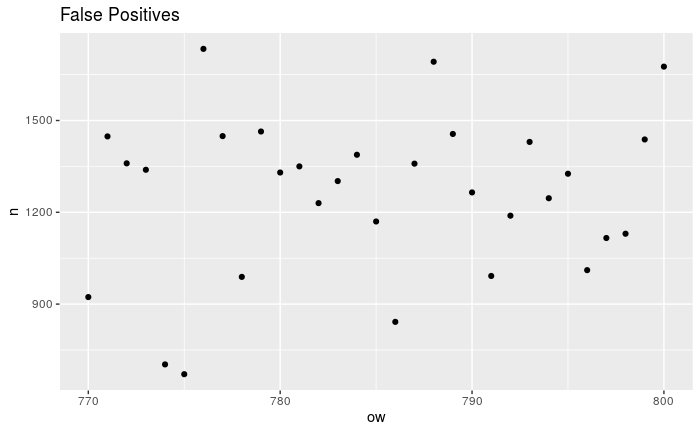

```r
graph_false_pos()
```

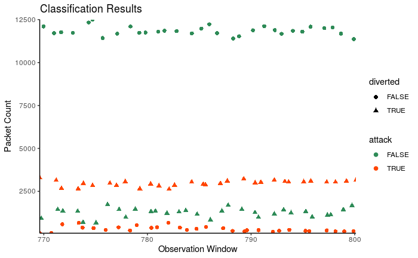

```r
graph_results()
```

```r
NA
NA
NA
```

**I finally have a graph that lets me see what’s going on over time!!!**

## All Attack OWs

```r
threshold = 16
```

Let’s see what happens when we move further toward the end:

```r
first = 770
last = 1280

query = packets %>% filter(ow>=first, ow<=last)

stats()
```

```
True evil: 1673844 True good: 6698380 Total: 8372224
Class evil: 2445589 Class good: 5926635 Total: 8372224
FNcount: 46617 FPcount: 818362 Total: 864979
FNR: 0.0279 FPR: 0.1222
```

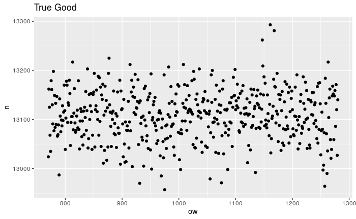

```r
query = packets %>%
  filter(ow>=first, ow<=last) %>%
  mutate(diverted=divert(src_delta,dst_delta)) %>%
  group_by(ow)

graph_true_good()
```

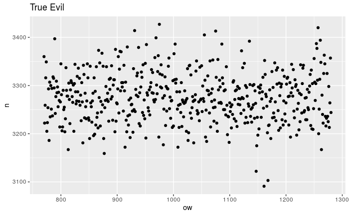

```r
graph_true_evil()
```

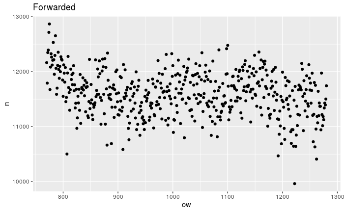

```r
graph_class_good()
```

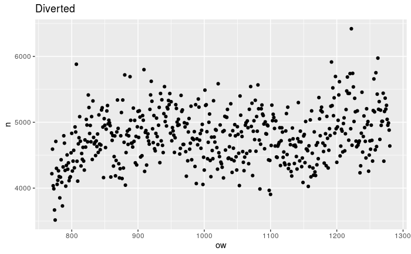

```r
graph_class_evil()
```

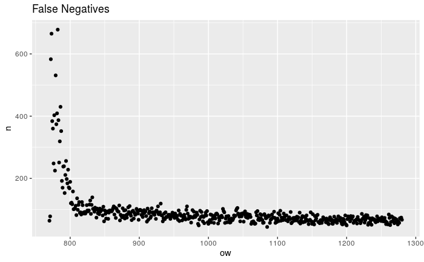

```r
graph_false_neg()
```

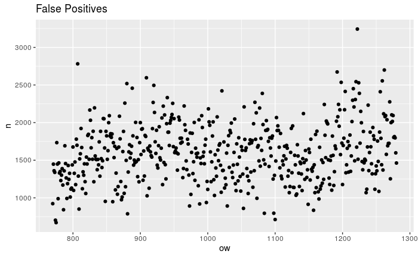

```r
graph_false_pos()
```

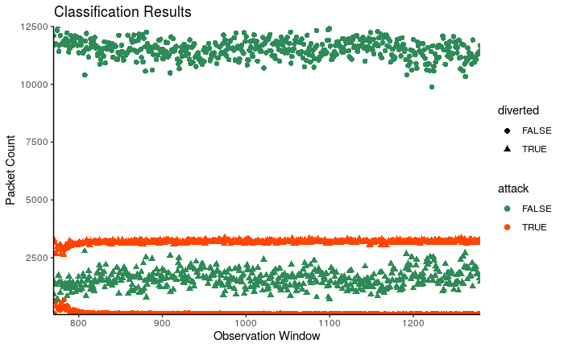

```r
graph_results()
```

```r
NA
NA
NA
NA
```

```r
packets %>%
  filter(ow>=first, ow<=last, attack==TRUE, divert(src_delta, dst_delta)==TRUE) %>%
  group_by(ow) %>%
  summarize(n = n()) %>%
  summarize(mean = mean(n) / (0.2 * 16384), margin = qnorm(0.975) * sd(n)/sqrt(1280-770+1) / (0.2 * 16384))
```

| mean | margin |
| --- | --- |
| 0.9718009 | 0.002221624 |

```r
NA
```

```r
packets %>%
  filter(ow>=first, ow<=last, attack==FALSE, divert(src_delta, dst_delta)==TRUE) %>%
  group_by(ow) %>%
  summarize(n = n()) %>%
  summarize(mean = mean(n) / (0.8 * 16384), margin = qnorm(0.975) * sd(n)/sqrt(1280-770+1) / (0.8 * 16384))
```

| mean | margin |
| --- | --- |
| 0.1221841 | 0.002537703 |

# Attack vs TCAD

Now it’s a good time to try to correlate these findings with TCAD measurements.

What are our chosen k coefficients?

Our experiments with **tcad_m_levels.py** show us candidate values for k, as follows:

| Log2(m) | k | FPR |
| --- | --- | --- |
| 13 | 4.000 | 1.8% |
| 14 | 4.125 | 1.7% |
| 15 | 4.250 | 1.8% |
| 16 | 4.500 | 1.6% |
| 17 | 4.750 | 1.6% |
| 18 | 3.625 | 0.0% |

TCAD measurements can be found in the following files:

tcad_m_2_14_k_4.125.log tcad_m_2_16_k_4.500.log tcad_m_2_18_k_3.625.log

[Source: DDoS Mitigation.ipynb, section Finding TCAD Values]

```r
col_names = c("ts",
              "src_ent",
              "src_ewma",
              "src_ewmmd",
              "dst_ent",
              "dst_ewma",
              "dst_ewmmd",
              "alarm")

col_types = "ciddiddl"

tcad_m14 = read_table2("~/p4sec/ddosm-p4/lab/ddos20/tcad_logs/tcad_m_2_14_k_4.125.log",
                       col_names = col_names,
                       col_types = col_types)

tcad_m14 = tcad_m14 %>% tibble::rowid_to_column("ow")

tcad_m14 = tcad_m14 %>% mutate(src_ent   = src_ent/16,
                               dst_ent   = dst_ent/16,
                               src_ewma  = src_ewma/262144,
                               dst_ewma  = dst_ewma/262144,
                               src_ewmmd = src_ewmmd/262144,
                               dst_ewmmd = dst_ewmmd/262144)

k = 4.125
```

## Entropy Overview

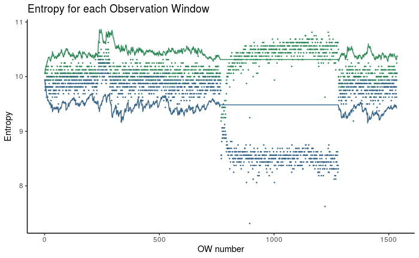

```r
base_plot = tcad_m14 %>% ggplot(mapping=aes(x=ow))

base_plot +
  labs(x="OW number", y="Entropy", title="Entropy for each Observation Window") +
  geom_point(mapping=aes(y=src_ent), size=0.25, color="seagreen4") +
  geom_point(mapping=aes(y=dst_ent), size=0.25, color="steelblue4") +
  geom_line(mapping=aes(y=src_ewma+k*src_ewmmd), color="seagreen4") +
  geom_line(mapping=aes(y=dst_ewma-k*dst_ewmmd), color="steelblue4") +
  theme_classic()
```

## Entropy Under Attack

Alright, we have the graph. Now we need to focus in the attack (OWs 768-1280).

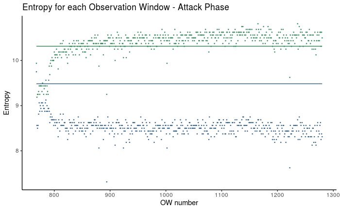

```r
base_plot = tcad_m14 %>% filter(ow>=768, ow<=1280) %>% ggplot(mapping=aes(x=ow))

base_plot +
  labs(x="OW number", y="Entropy", title="Entropy for each Observation Window - Attack Phase") +
  geom_point(mapping=aes(y=src_ent), size=0.25, color="seagreen4") +
  geom_point(mapping=aes(y=dst_ent), size=0.25, color="steelblue4") +
  geom_line(mapping=aes(y=src_ewma+k*src_ewmmd), color="seagreen4") +
  geom_line(mapping=aes(y=dst_ewma-k*dst_ewmmd), color="steelblue4") +
  theme_classic()
```

Let’s copy these data to specific tibbles.

```r
first = 770
last = 1280

attack_entropy = tcad_m14 %>% filter(ow>=first, ow<=last) %>% mutate(ow=ow-512)

attack_entropy
```

| ow | ts | src_ent | src_ewma | src_ewmmd | dst_ent | dst_ewma | dst_ewmmd | alarm |
| --- | --- | --- | --- | --- | --- | --- | --- | --- |
| 258 | 1459947791556006 | 9.2500 | 10.02806 | 0.06950378 | 8.5000 | 9.814529 | 0.08008194 | TRUE |
| 259 | 1459947791568356 | 9.2500 | 10.02806 | 0.06950378 | 8.5625 | 9.814529 | 0.08008194 | TRUE |
| 260 | 1459947791580175 | 9.3125 | 10.02806 | 0.06950378 | 8.8125 | 9.814529 | 0.08008194 | TRUE |
| 261 | 1459947791592198 | 9.4375 | 10.02806 | 0.06950378 | 9.0625 | 9.814529 | 0.08008194 | TRUE |
| 262 | 1459947791604057 | 9.2500 | 10.02806 | 0.06950378 | 8.8750 | 9.814529 | 0.08008194 | TRUE |
| 263 | 1459947791616670 | 9.4375 | 10.02806 | 0.06950378 | 9.0000 | 9.814529 | 0.08008194 | TRUE |
| 264 | 1459947791629242 | 9.4375 | 10.02806 | 0.06950378 | 8.9375 | 9.814529 | 0.08008194 | TRUE |
| 265 | 1459947791641449 | 9.4375 | 10.02806 | 0.06950378 | 9.0625 | 9.814529 | 0.08008194 | TRUE |
| 266 | 1459947791653825 | 9.3125 | 10.02806 | 0.06950378 | 8.8750 | 9.814529 | 0.08008194 | TRUE |
| 267 | 1459947791666254 | 9.5000 | 10.02806 | 0.06950378 | 9.0625 | 9.814529 | 0.08008194 | TRUE |

[output cut: 501 more lines]

```r
mitigation_out = packets %>%
  filter(ow>=first, ow<=last) %>%
  mutate(diverted=(src_delta>=threshold)) %>%
  group_by(ow, attack, diverted) %>%
  summarize(n=n())

mitigation_out
```

| ow | attack | diverted | n |
| --- | --- | --- | --- |
| 770 | FALSE | FALSE | 11919 |
| 770 | FALSE | TRUE | 1105 |
| 770 | TRUE | FALSE | 19 |
| 770 | TRUE | TRUE | 3341 |
| 771 | FALSE | FALSE | 12035 |
| 771 | FALSE | TRUE | 1127 |
| 771 | TRUE | FALSE | 63 |
| 771 | TRUE | TRUE | 3159 |
| 772 | FALSE | FALSE | 11576 |
| 772 | FALSE | TRUE | 1549 |

[output cut: 990 more lines]

```r
NA
NA
NA
```

## Typical Frequency Deltas

Question: for each OW, what are the typical frequency deltas (current OW - OW#768) for attack packets?

```r
#query = packets %>%
#  filter(ow>=first, ow<=last, attack==TRUE) %>%
#  group_by(ow) %>%
#  summarize(n=n(),q1=quantile(src_delta,0.25),q2=median(src_delta),q3=quantile(src_delta,0.75),iqr=IQR(src_delta))
#

query = packets %>%
  filter(ow>=first, ow<=last) %>%
  group_by(ow, attack) %>%
  summarize(q1=quantile(src_delta,0.25),
            q2=median(src_delta),
            q3=quantile(src_delta,0.75),
            iqr=IQR(src_delta),
            dq1=quantile(dst_delta,0.25),
            dq2=median(dst_delta),
            dq3=quantile(dst_delta,0.75),
            diqr=IQR(dst_delta))

query
```

| ow | attack | q1 | q2 | q3 | iqr | dq1 | dq2 | dq3 | diqr |
| --- | --- | --- | --- | --- | --- | --- | --- | --- | --- |
| 770 | FALSE | -8.00 | -1.0 | 4.00 | 12.00 | -11.00 | -1 | 3.00 | 14.00 |
| 770 | TRUE | 541.00 | 560.0 | 690.00 | 149.00 | 3271.00 | 3271 | 3271.00 | 0.00 |
| 771 | FALSE | -7.00 | -1.0 | 5.00 | 12.00 | -6.00 | 0 | 5.00 | 11.00 |
| 771 | TRUE | 540.00 | 540.0 | 763.00 | 223.00 | 3284.00 | 3284 | 3284.00 | 0.00 |
| 772 | FALSE | -7.00 | -1.0 | 5.00 | 12.00 | -7.00 | 0 | 6.00 | 13.00 |
| 772 | TRUE | 74.00 | 490.0 | 622.00 | 548.00 | 3144.00 | 3144 | 3144.00 | 0.00 |
| 773 | FALSE | -7.00 | -1.0 | 4.00 | 11.00 | -8.00 | -1 | 4.00 | 12.00 |
| 773 | TRUE | 23.00 | 416.0 | 602.00 | 579.00 | 26.00 | 2646 | 2646.00 | 2620.00 |
| 774 | FALSE | -7.00 | -1.0 | 4.00 | 11.00 | -10.00 | -1 | 4.00 | 14.00 |
| 774 | TRUE | 107.00 | 249.0 | 1060.00 | 953.00 | 114.00 | 2252 | 2252.00 | 2138.00 |

[output cut: 990 more lines]

```r
NA
```

Can we graph it?

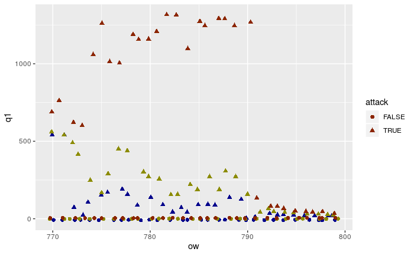

```r
dot_size = 2.0

query %>%
  filter(ow<800) %>%
  ggplot(mapping = aes(x=ow, shape=attack)) +
  geom_point(mapping = aes(y=q1), color="blue4", position="jitter", size=dot_size) +
  geom_point(mapping = aes(y=q2), color="yellow4", position="jitter", size=dot_size) +
  geom_point(mapping = aes(y=q3), color="orangered4", position="jitter", size=dot_size)
```

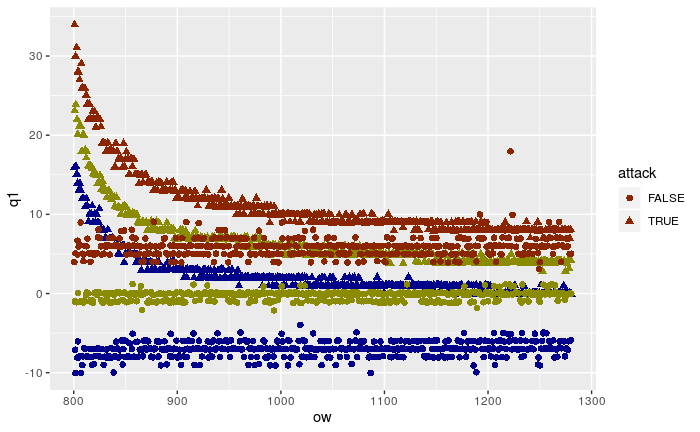

```r
  #coord_trans(y="log10")

query %>%
  filter(ow>800) %>%
  ggplot(mapping = aes(x=ow, shape=attack)) +
  geom_point(mapping = aes(y=q1), color="blue4", position="jitter", size=dot_size) +
  geom_point(mapping = aes(y=q2), color="yellow4", position="jitter", size=dot_size) +
  geom_point(mapping = aes(y=q3), color="orangered4", position="jitter", size=dot_size) #+
```

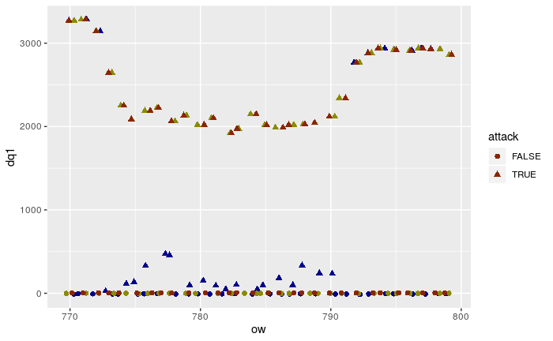

```r
  #coord_trans(y="log10")

query %>%
  filter(ow<800) %>%
  ggplot(mapping = aes(x=ow, shape=attack)) +
  geom_point(mapping = aes(y=dq1), color="blue4", position="jitter", size=dot_size) +
  geom_point(mapping = aes(y=dq2), color="yellow4", position="jitter", size=dot_size) +
  geom_point(mapping = aes(y=dq3), color="orangered4", position="jitter", size=dot_size)
```

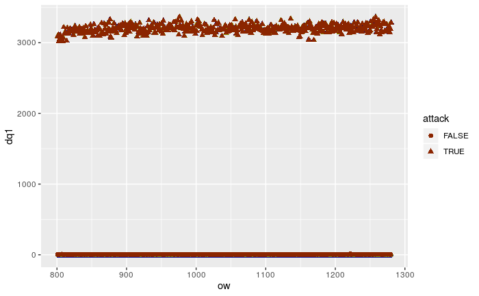

```r
  #coord_trans(y="log10")

query %>%
  filter(ow>800) %>%
  ggplot(mapping = aes(x=ow, shape=attack)) +
  geom_point(mapping = aes(y=dq1), color="blue4", position="jitter", size=dot_size) +
  geom_point(mapping = aes(y=dq2), color="yellow4", position="jitter", size=dot_size) +
  geom_point(mapping = aes(y=dq3), color="orangered4", position="jitter", size=dot_size) #+
```

```r
  #coord_trans(y="log10")
```

## Points to Ponder

For each OW, how many different attack sources are there?

How are these deltas related to entropy?

What else can we do?

```r
rm(query)
```